# tidyverse

## tidying functions: `spread()`

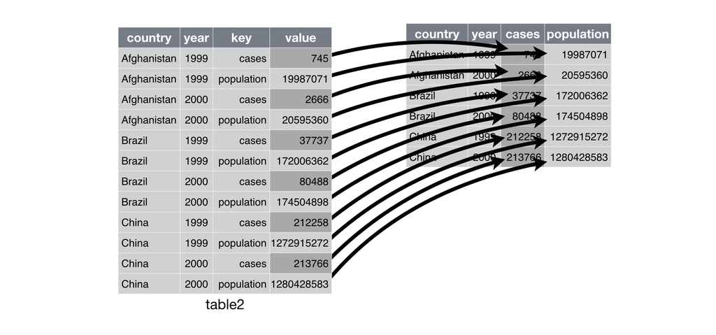

Replace reshape (R) and/or “pivot” (Excel) table function.

http://tidyr.tidyverse.org/

## tidying with `spread()`

```r
spread(table2, key = type, value = count)
```

```
## # A tibble: 6 x 4
##   country      year  cases population
##   <chr>       <int>  <int>      <int>
## 1 Afghanistan  1999    745   19987071
## 2 Afghanistan  2000   2666   20595360
## 3 Brazil       1999  37737  172006362
## 4 Brazil       2000  80488  174504898
## 5 China        1999 212258 1272915272
## 6 China        2000 213766 1280428583
```

The `gather()` function does the opposite (i.e., “unpivots”)

## tidy principle

Functions are easiest to use when they are:

1. **Simple**: They do one thing, and they do it well
2. **Composable**: They can be combined with other functions for multi-step operations

## Core packages: dplyr, ggplot2, piping (%>%)

## dplyr: Data Munging/Transformation

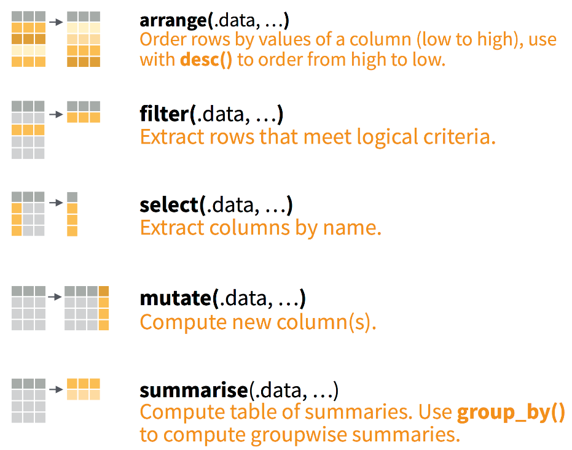

http://dplyr.tidyverse.org/ [dplyr cheatsheet](https://www.rstudio.com/wp-content/uploads/2015/02/data-wrangling-cheatsheet.pdf)

## dplyr

Load csv (readr)…

```r
tweets <- read_csv("../data/CharlotteTweets20Sample.csv") # readr function

select(tweets, body, postedTime, geo.type, point_long, point_lat) # view relevant columns
```

```
## # A tibble: 47,274 x 5
##    body                  postedTime          geo.type point_long point_lat
##    <chr>                 <dttm>              <chr>         <dbl>     <dbl>
##  1 Treon to WR is a rea… 2016-02-05 17:23:34 Polygon        NA        NA
##  2 primus #vsco #vscoca… 2016-01-28 00:20:32 Point          35.2     -80.8
##  3 WOAH!!!!!!            2015-12-05 01:05:22 Polygon        NA        NA
##  4 clear -&gt; mostly c… 2015-12-12 04:54:38 Point          35.5     -80.6
##  5 Slutty 7 keeps me up… 2016-01-17 07:01:15 Polygon        NA        NA
##  6 Need to grab a quick… 2015-12-10 19:16:02 Point          35.1     -80.8
##  7 @AaronCarpenter #Mag… 2016-01-20 01:24:54 Polygon        NA        NA
##  8 @The_BigKahunaa beca… 2015-12-17 23:25:26 Polygon        NA        NA
##  9 @KyleBusch @KBMteam … 2016-01-27 21:35:25 Polygon        NA        NA
## 10 Praying for my 704 f… 2015-12-24 20:23:19 Polygon        NA        NA
## # ... with 47,264 more rows
```

## dplyr

Load csv (readr) and use dplyr functions.

```r
tweets <- read_csv("../data/CharlotteTweets20Sample.csv") # readr function

df <- group_by(tweets, geo.type) # group rows by column geo.type

summarise(df, Count = n()) # summarise (count) rows by geo.type
```

```
## # A tibble: 2 x 2
##   geo.type Count
##   <chr>    <int>
## 1 Point    21683
## 2 Polygon  25591
```

## dplyr with piping (%>%)

```r
df <- group_by(tweets, geo.type)
summarise(df, Count = n())
```

```
## # A tibble: 2 x 2
##   geo.type Count
##   <chr>    <int>
## 1 Point    21683
## 2 Polygon  25591
```

```r
tweets %>%
  group_by(geo.type) %>%
  summarise(Count=n())
```

```
## # A tibble: 2 x 2
##   geo.type Count
##   <chr>    <int>
## 1 Point    21683
## 2 Polygon  25591
```

## Piping gets really helpful for long commands…

```r
tweets %>%
  group_by(actor.location.displayName) %>%
  summarise(Count=n()) %>%
  arrange(desc(Count)) %>%
  head(n=5)
```

```
## # A tibble: 5 x 2
##   actor.location.displayName Count
##   <chr>                      <int>
## 1 <NA>                       10655
## 2 Charlotte, NC               9270
## 3 Kannapolis, NC               962
## 4 Huntersville, NC             823
## 5 North Carolina               657
```

[figure not shown]

## ggplot2: Visualizations

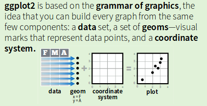

http://ggplot2.tidyverse.org/ [ggplot2 cheatsheet](https://www.rstudio.com/wp-content/uploads/2015/03/ggplot2-cheatsheet.pdf)

## ggplot2: Visualizations

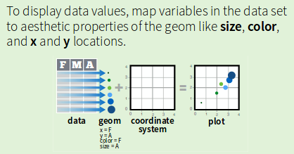

## ggplot2: Visualizations

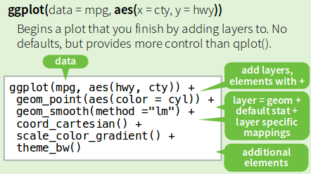

## ggplot2: Visualizations

```r
head(df, n = 5)
```

```
## # A tibble: 5 x 2
##   actor.location.displayName Count
##   <fct>                      <int>
## 1 <NA>                       10655
## 2 Charlotte, NC               9270
## 3 Kannapolis, NC               962
## 4 Huntersville, NC             823
## 5 North Carolina               657
```

## ggplot2: Visualizations

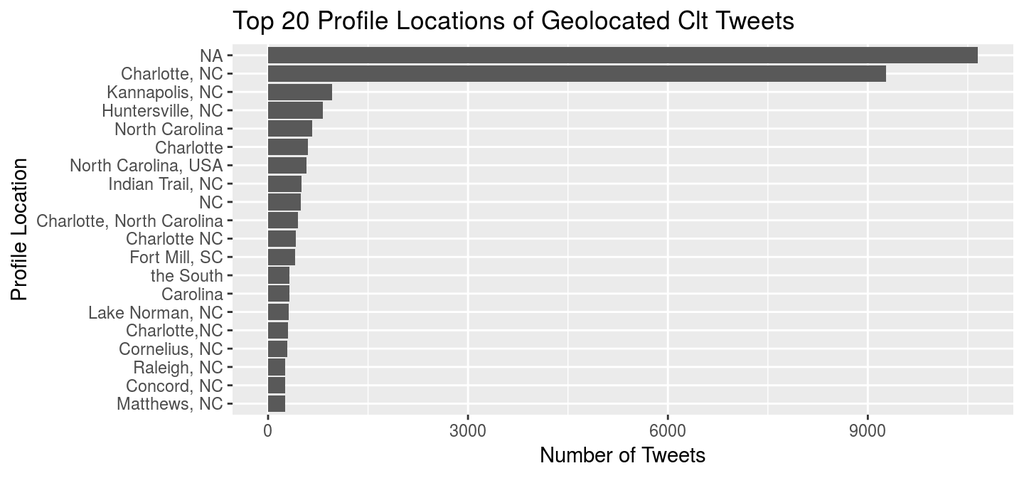

[figure not shown]

```r
ggplot(df, aes(x = actor.location.displayName, y = Count)) +
  geom_bar(stat = "identity") +
  coord_flip() +
  labs(x = "Profile Location", y = "Number of Tweets",
       title = "Top 20 Profile Locations of Geolocated Clt Tweets")
```

[ggplot2 cheatsheet](https://www.rstudio.com/wp-content/uploads/2015/03/ggplot2-cheatsheet.pdf)

## ggplot example: gganimate

```r
wkdy <- c("Sunday", "Monday", "Tuesday", "Wednesday", "Thursday", "Friday", "Saturday")

df2 <- tweets %>%
  mutate(Hour = format(postedTime, format="%H"),
           Weekday = weekdays(as.Date(postedTime)),
           Date = as.Date(postedTime)) %>%
  group_by(Hour, Weekday, Date) %>%
  summarise(Count=n()) %>%
  ungroup() %>%
  mutate(Weekday = factor(Weekday, levels = wkdy))

head(df2, n=2)
```

```
## # A tibble: 2 x 4
##   Hour  Weekday Date       Count
##   <chr> <fct>   <date>     <int>
## 1 00    Friday  2015-12-04    19
## 2 00    Friday  2015-12-11    11
```

## ggplot example: gganimate

```r
g <- ggplot(df2, aes(x = Hour, y = Count, frame = Weekday)) +
  geom_boxplot(width = 1) +
  labs(x = "Hour", y = "Number of Tweets",
       title = "Timing of Charlotte Geolocated Tweets by Day:",
       caption = "Tweets from Dec 2015 - Feb 2016") +
  theme(legend.position = "bottom")

gganimate(g, interval = 3)
```

[output not shown]

## ggplot extensions

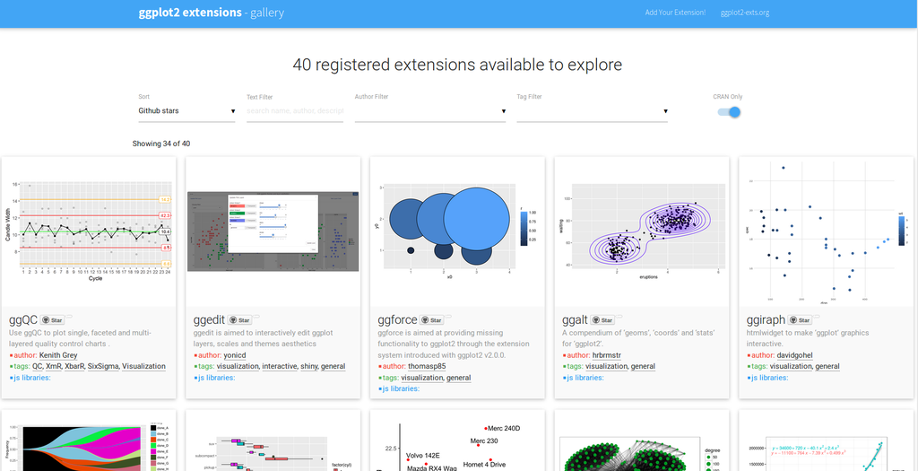

[ggextensions](http://www.ggplot2-exts.org/gallery/)

## tidyverse advanced packages

## purrr: functional programming

Let’s start with the starwars dataset.

```r
head(starwars, n=5)
```

```
## # A tibble: 5 x 4
##   name           height  mass species
##   <chr>           <int> <dbl> <chr>
## 1 Luke Skywalker    172   77. Human
## 2 C-3PO             167   75. Droid
## 3 R2-D2              96   32. Droid
## 4 Darth Vader       202  136. Human
## 5 Leia Organa       150   49. Human
```

## purrr: functional programming

```r
starwars %>%
  mutate(species2 = ifelse(species == "Human", "Human", "non-Human")) %>%
  split(.$species2) %>% # from base R
  map(~ lm(mass ~ height, data = .)) %>% # linear regression
  map(summary) %>% # keep the summary output
  map_dbl("r.squared")
```

```
##      Human  non-Human
## 0.42465096 0.01932538
```

http://purrr.tidyverse.org/

## broom: analyze model results

```r
lmFit <- starwars %>%
  mutate(species2 = ifelse(species == "Human", "Human", "non-Human")) %>%
  split(.$species2) %>% # from base R
  map(~ lm(mass ~ height, data = .))
```

```r
library(broom)
tidy(lmFit[[1]]) # regression for human
```

```
##          term    estimate  std.error statistic     p.value
## 1 (Intercept) -116.582591 51.9891504 -2.242441 0.036425452
## 2      height    1.110384  0.2890067  3.842071 0.001017536
```

```r
tidy(lmFit[[2]]) # regression for non-human
```

```
##          term  estimate   std.error   statistic   p.value
## 1 (Intercept) -7.941615 145.7080170 -0.05450363 0.9568529
## 2      height  0.677325   0.8274773  0.81854206 0.4187480
```

https://cran.r-project.org/web/packages/broom/vignettes/broom.html

## rvest for webscraping

```r
library(rvest)
lego_movie <- read_html("http://www.imdb.com/title/tt1490017/")

lego_movie %>%
  html_nodes("strong span") %>%
  html_text() %>%
  as.numeric()
```

```
## [1] 7.8
```

## rvest for webscraping

```r
lego_movie %>%
  html_nodes("#titleCast .itemprop span") %>%
  html_text()
```

```
##  [1] "Will Arnett"     "Elizabeth Banks" "Craig Berry"
##  [4] "Alison Brie"     "David Burrows"   "Anthony Daniels"
##  [7] "Charlie Day"     "Amanda Farinos"  "Keith Ferguson"
## [10] "Will Ferrell"    "Will Forte"      "Dave Franco"
## [13] "Morgan Freeman"  "Todd Hansen"     "Jonah Hill"
```

https://github.com/hadley/rvest

[SelectorGadget](https://cran.r-project.org/web/packages/rvest/vignettes/selectorgadget.html)

## tidytext for simple text analysis

```r
library(tidytext)
tidy_tweets <- tweets %>%
  unnest_tokens(word, body) %>% # tokenize body column
  anti_join(stop_words) %>% # remove stop words
  count(word, sort = TRUE) # count by tokens

head(tidy_tweets, n = 5)
```

```
## # A tibble: 5 x 2
##   word          n
##   <chr>     <int>
## 1 charlotte  5672
## 2 nc         3328
## 3 love       1485
## 4 day        1344
## 5 carolina   1240
```

https://cran.r-project.org/web/packages/tidytext/vignettes/tidytext.html

## More advanced tidytext

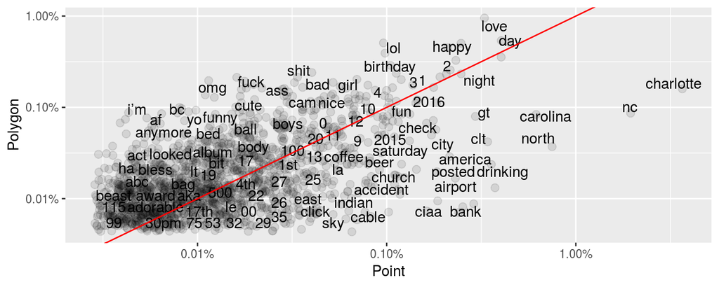

```r
ggplot(groupedTweets, aes(x = Point, y = Polygon)) +
  geom_jitter(alpha = 0.1, size = 2.5, width = 0.1, height = 0.1) +
  geom_text(aes(label = word), check_overlap = TRUE, vjust = 0.5) +
  scale_x_log10(labels = percent_format()) + scale_y_log10(labels = percent_format()) +
  geom_abline(color = "red")
```

[tidytext Book](https://www.tidytextmining.com/twitter.html#comparing-word-usage)

## Other important packages

- Reading in SPSS, SAS, STATA: **haven** http://haven.tidyverse.org/
- Reading in Excel files: **readxl** http://readxl.tidyverse.org/
- Date/time formats: **lubridate** http://lubridate.tidyverse.org/
- Strings: **stringr** http://stringr.tidyverse.org/
- Factors: **forcats** http://forcats.tidyverse.org/
- Package Management: **packrat** https://rstudio.github.io/packrat/

## R Markdown for Replication

This document is a R Markdown presentation (ioslides).

[figure not shown]

For examples on using R Markdown, see http://rmarkdown.rstudio.com/gallery.html.